# Lab 5

Christopher Spartz

11/11/2021

```r
acc <- read.csv("https://raw.githubusercontent.com/xdaiISU/ds202materials/master/hwlabs/fars2017/accident.csv", stringsAsFactors = FALSE)
person <- read.csv("https://raw.githubusercontent.com/xdaiISU/ds202materials/master/hwlabs/fars2017/person.csv", stringsAsFactors = FALSE)
library(ggplot2)
library(tidyverse)
library(lubridate)
```

## 1. Fatal Accidents

```r
fatalities <- person %>% filter(INJ_SEV==4)
head(fatalities,5)
```

```
##   STATE ST_CASE VE_FORMS VEH_NO PER_NO STR_VEH COUNTY DAY MONTH HOUR MINUTE
## 1     1   10001        1      1      1       0     73  19     2   23     35
## 2     1   10002        1      1      1       0     89  14     2   14     59
## 3     1   10003        3      2      1       0    101  31     1   20     31
## 4     1   10004        1      1      1       0     73   1     1   16     55
## 5     1   10005        1      1      1       0     13   1     1   20      0
##   RUR_URB FUNC_SYS HARM_EV MAN_COLL SCH_BUS MAKE MAK_MOD BODY_TYP MOD_YEAR
## 1       2        1      38        0       0   20   20421       15     2004
## 2       2        1       1        0       0   37   37402       14     2005
## 3       2        1      12        1       0    2    2404       14     2003
## 4       2        4      30        0       0   30   30046        4     2014
## 5       1        1      35        0       0   12   12471       34     2010
##   TOW_VEH SPEC_USE EMER_USE ROLLOVER IMPACT1 FIRE_EXP AGE SEX PER_TYP INJ_SEV
## 1       1        0        0        0      12        0  42   1       1       4
## 2       0        0        0        9       0        0  43   1       1       4
```

[output cut: 33 more lines]

## 2. Most Dangerous Manufacturer

```r
dangerVehicles <- fatalities %>% group_by(MAKE) %>% summarise(fatalities = n())
dangerVehicles
```

```
## # A tibble: 66 × 2
##     MAKE fatalities
##    <int>      <int>
##  1     2        692
##  2     3         13
##  3     6        573
##  4     7       1578
##  5     8          1
##  6     9         35
##  7    10          2
##  8    12       3998
##  9    13        207
## 10    14        316
## # … with 56 more rows
```

## 3. Most Dangeour Manufacturer per State

```r
GLC <- readxl::read_xlsx("GLC.xlsx")
GLC <- GLC %>% rename(STATE="State Code")
GLC <- GLC %>% rename(NAME="State Name")
GLC$STATE <- as.integer(GLC$STATE)
sf <- fatalities %>% select(STATE,MAKE) %>% drop_na(MAKE)
state <- GLC %>% group_by(STATE,NAME) %>% distinct(STATE,NAME)
sfs <- state %>% inner_join(sf)
smf <- sfs %>% group_by(NAME,MAKE) %>% summarise(deaths=n()) %>%
  top_n(1, deaths)
```

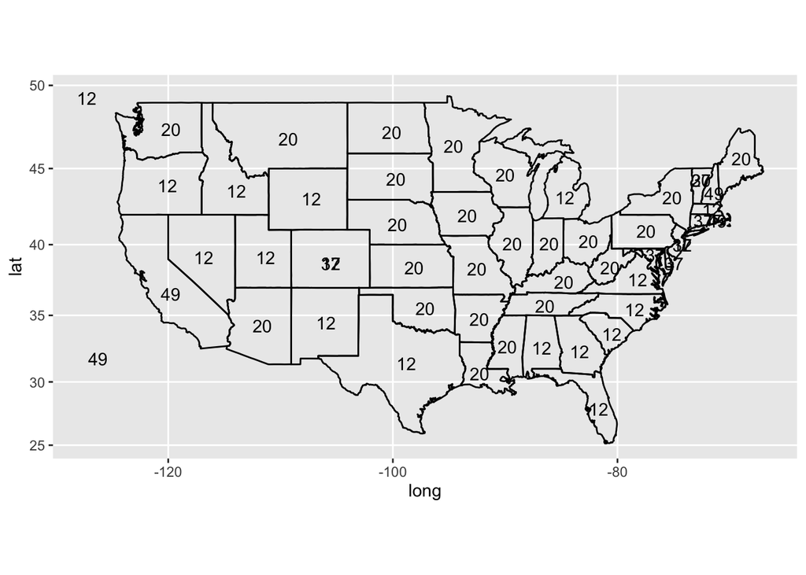

```r
states <- map_data("state")
snames <- data.frame(region=tolower(state.name), long=state.center$x, lat=state.center$y)
smf <- smf %>% mutate(region = tolower(NAME)) %>% inner_join(snames)
states %>% ggplot(aes(x = long, y = lat)) +
  geom_path(aes(group = group)) +
  coord_map() +
  geom_text(data=smf, aes(long, lat, label=MAKE))
```

The most dangerous vehicle in this scenario is the make involved in the most fatal accidents, and it looks like the most dangerous make in the US is Chevrolet, who has the most fatal accidents in the majority of US states.

## 4. Joining Person and Accidents

```r
pacc <- person %>% inner_join(acc,by=c("STATE","COUNTY","DAY","MONTH","HOUR","MINUTE"))
```

## 5. Accidents by DAY, HOUR, SEX

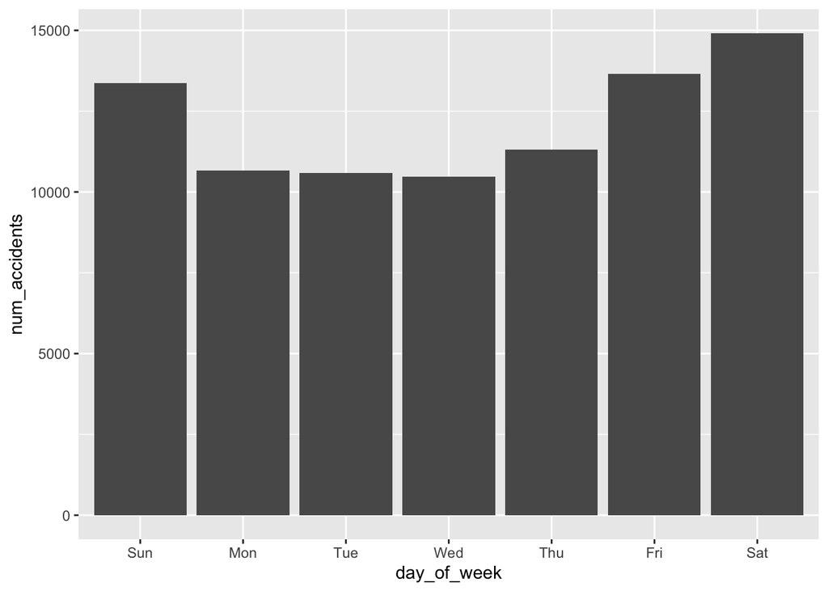

```r
pacc %>% group_by(DAY_WEEK) %>% summarise(num_accidents=n()) %>% mutate(day_of_week  = wday(DAY_WEEK, label = TRUE)) %>%
  ggplot(aes(x=day_of_week,y=num_accidents)) + geom_bar(stat = "Identity")
```

Most accidents tend to happen on the weekends, which makes sense since that is the time when people are most likely to go out drinking, and when people drink and drive they tend to get into more accidents.

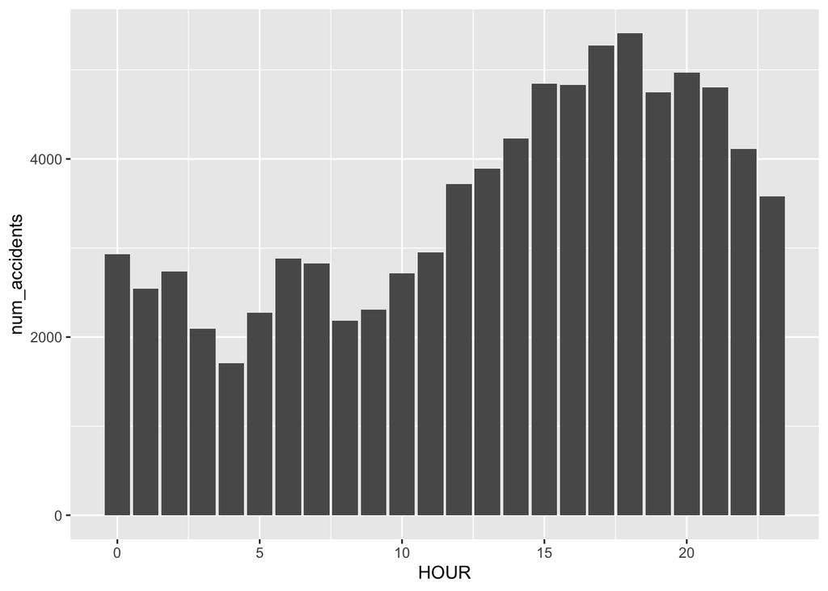

```r
pacc %>% group_by(HOUR) %>% filter(HOUR<25) %>% summarise(num_accidents=n()) %>%
  ggplot(aes(x=HOUR,y=num_accidents)) + geom_bar(stat = "Identity")
```

Accidents tend to happen more in the afternoon and evening, specifically in the period of 3pm until 9pm, which encompasses the entirety of the normal rush hour, the times when a lot of people are on the road since they are trying to get home from work. This time period also coincides with the times when people go out to eat or go to the bar, and when they finish eating and drinking they try to drive while drunk, resulting in an accident.

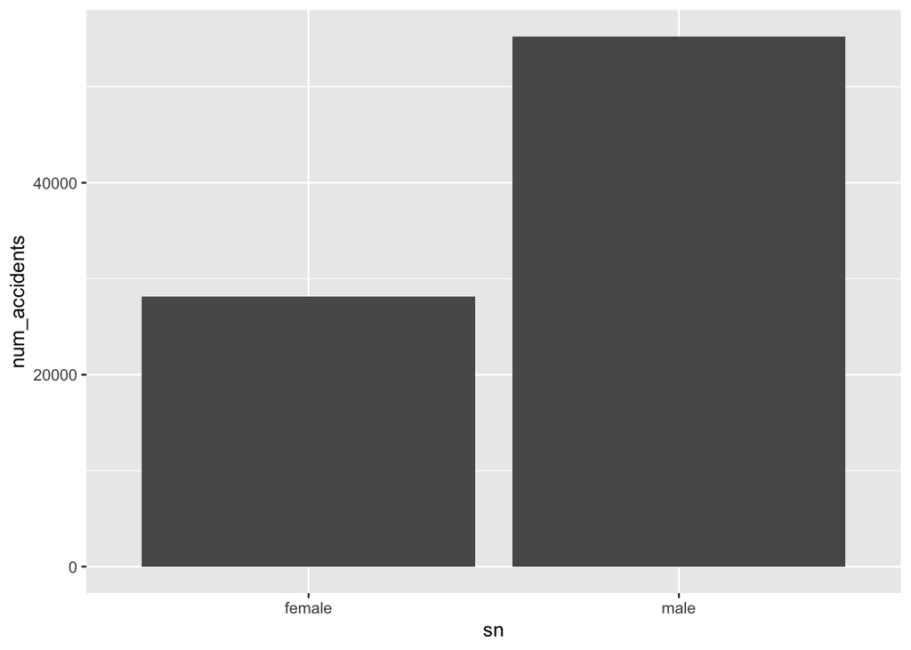

```r
paccF <- pacc %>%  filter(SEX<3)
paccF %>% mutate(sn = ifelse(paccF$SEX == 1, "male", "female")) %>% group_by(sn)  %>% summarise(num_accidents=n()) %>%
  ggplot(aes(x=sn,y=num_accidents)) + geom_bar(stat = "Identity")
```

## 6. Map of Deaths on a County level

```r
GLC <- GLC %>% rename(COUNTY="County Code")
GLC <- GLC %>% rename(CN="County Name")
GLC$COUNTY <- as.integer(GLC$COUNTY)
cf <- fatalities %>% select(COUNTY) %>% drop_na(COUNTY)
county <- GLC %>% group_by(COUNTY,CN) %>% distinct(COUNTY,CN)
cfc <- county %>% inner_join(cf) %>% summarise(deaths=n())
```

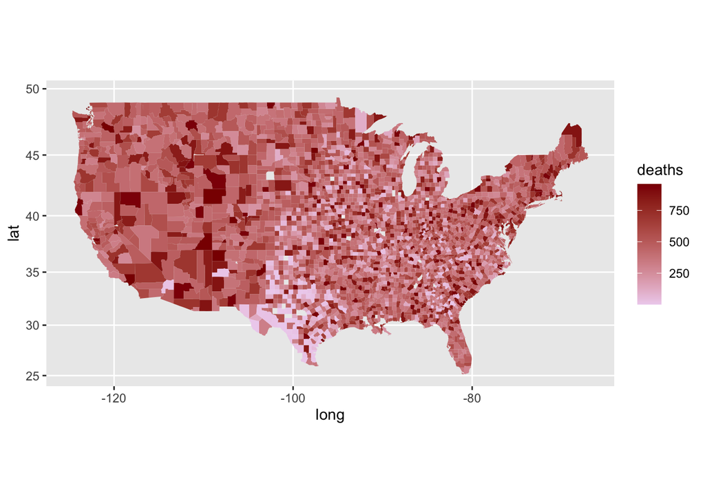

```r
counties <- map_data("county")
counties <- cfc %>% mutate(subregion=tolower(CN)) %>% inner_join(counties, by="subregion")
counties %>% ggplot(aes(x = long, y = lat)) +
  geom_polygon(aes(group = group,fill=deaths)) +
  coord_map()+scale_fill_continuous(low="thistle2", high="darkred",
                       guide="colorbar",na.value="white")
```